# DAR F23 Hockey Analytics

Hockey Analytics

Jeff Jung

2023-10-16

## Weekly Work Summary

**NOTE:** Follow an outline format; use bullets to express individual points.

- RCS ID: jungj6
- Project Name: Hockey Analytics

Summary of work since last week

- Last week, I have successfully categorized continuous variables into categories, and this week, I did further analysis with categorical data
- Created bar plots to show the modes categorized variable with saves data
- Created heat map, which required converting all categorical data into binary variables
- Heat map effectively showed the correlations between different categories of each feature

NEW: Summary of github issues added and worked

N/A

Summary of github commits

- One commit of HW4 to dar-jungj6

List of presentations, papers, or other outputs

N/A

## Personal Contribution

- Analysis on the modes of failure with categorization
- Application of bar plots in illustrating different modes of failure with categorization
- Application of heat map in illustration different modes of failure with categorization

## Analysis: Modes of Failure

### Question being asked

Since we do not have much data for goals, I have decided to do further analysis on saves. Finding the modes of failure would allow me to identify what features of shots led to saves.

### Data Preparation

Data preparation for hockeyTrain is the same as I did for other assignments. Since I am specifically examining the modes of failure, I have separated ‘saves’ from hockeyTrain. Also, I have categorized continuous variables into 3 groups (high, med, low), so that it is easier to visualize.

```r
# Load necessary library
library(dplyr)

# Calculate quantiles to divide the data into thirds
puckDist_q <- quantile(hockeyTrain$puckDist, probs = c(1/3, 2/3))
puckAngle_q <- quantile(hockeyTrain$puckAngle, probs = c(1/3, 2/3))
puckSpeed_q <- quantile(hockeyTrain$puckSpeed, probs = c(1/3, 2/3))
shooterSpeed_q <- quantile(hockeyTrain$shooterSpeed, probs = c(1/3, 2/3))
goalieDist_q <- quantile(hockeyTrain$goalieDist, probs = c(1/3, 2/3))
goalieAngle_q <- quantile(hockeyTrain$goalieAngle, probs = c(1/3, 2/3))
posTime_q <- quantile(hockeyTrain$posTime, probs = c(1/3, 2/3))

# Create three categories based on quantiles
hockeyTrain <- hockeyTrain %>%
  mutate(puckSpeedCategory = case_when(
    puckSpeed <= puckSpeed_q[1] ~ "Low",
    puckSpeed <= puckSpeed_q[2] ~ "Medium",
    TRUE ~ "High"
  ))

hockeyTrain <- hockeyTrain %>%
  mutate(puckDistCategory = case_when(
    puckDist <= puckDist_q[1] ~ "Low",
    puckDist <= puckDist_q[2] ~ "Medium",
    TRUE ~ "High"
  ))

hockeyTrain <- hockeyTrain %>%
  mutate(puckAngleCategory = case_when(
    puckAngle <= puckAngle_q[1] ~ "Low",
    puckAngle <= puckAngle_q[2] ~ "Medium",
    TRUE ~ "High"
  ))

hockeyTrain <- hockeyTrain %>%
  mutate(shooterSpeedCategory = case_when(
    shooterSpeed <= shooterSpeed_q[1] ~ "Low",
    shooterSpeed <= shooterSpeed_q[2] ~ "Medium",
    TRUE ~ "High"
  ))

hockeyTrain <- hockeyTrain %>%
  mutate(goalieDistCategory = case_when(
    goalieDist <= goalieDist_q[1] ~ "Low",
    goalieDist <= goalieDist_q[2] ~ "Medium",
    TRUE ~ "High"
  ))

hockeyTrain <- hockeyTrain %>%
  mutate(goalieAngleCategory = case_when(
    goalieAngle <= goalieAngle_q[1] ~ "Low",
    goalieAngle <= goalieAngle_q[2] ~ "Medium",
    TRUE ~ "High"
  ))

hockeyTrain <- hockeyTrain %>%
  mutate(posTimeCategory = case_when(
    posTime <= posTime_q[1] ~ "Low",
    posTime <= posTime_q[2] ~ "Medium",
    TRUE ~ "High"
  ))

# Subset the data for not goals (e.g., "Save")
saves_data <- hockeyTrain[hockeyTrain$outcomes.goal != "1", ]
```

### Analysis: Methods and results

First, I have created a bar chart to show what the mode groups are for each variable. And then, to show how each feature is correlated with other features, I have created a heatmap.

```r
# Include all analysis code, clearly commented
# If not possible, screen shots are acceptable.
# If your contributions included things that are not done in an R-notebook,
#   (e.g. researching, writing, and coding in Python), you still need to do
#   this status notebook in R.  Describe what you did here and put any products
#   that you created in github. If you are writing online documents (e.g. overleaf
#   or google docs), you can include links to the documents in this notebook
#   instead of actual text.

# Find modes for each variable
mode_puckSpeed <- names(sort(table(saves_data$puckSpeedCategory), decreasing = TRUE)[1])
mode_puckDist <- names(sort(table(saves_data$puckDistCategory), decreasing = TRUE)[1])
mode_puckAngle <- names(sort(table(saves_data$puckAngleCategory), decreasing = TRUE)[1])
mode_shooterSpeed <- names(sort(table(saves_data$shooterSpeedCategory), decreasing = TRUE)[1])
mode_goalieDist <- names(sort(table(saves_data$goalieDistCategory), decreasing = TRUE)[1])
mode_goalieAngle <- names(sort(table(saves_data$goalieAngleCategory), decreasing = TRUE)[1])
mode_posTime <- names(sort(table(saves_data$posTimeCategory), decreasing = TRUE)[1])

# Print the modes for each variable
cat("Mode for puckSpeedCategory:", mode_puckSpeed, "\n")
```

```
## Mode for puckSpeedCategory: Medium
```

```r
cat("Mode for puckDistCategory:", mode_puckDist, "\n")
```

```
## Mode for puckDistCategory: High
```

```r
cat("Mode for puckAngleCategory:", mode_puckAngle, "\n")
```

```
## Mode for puckAngleCategory: Low
```

```r
cat("Mode for shooterSpeedCategory:", mode_shooterSpeed, "\n")
```

```
## Mode for shooterSpeedCategory: Medium
```

```r
cat("Mode for goalieDistCategory:", mode_goalieDist, "\n")
```

```
## Mode for goalieDistCategory: High
```

```r
cat("Mode for goalieAngleCategory:", mode_goalieAngle, "\n")
```

```
## Mode for goalieAngleCategory: Medium
```

```r
cat("Mode for posTimeCategory:", mode_posTime, "\n")
```

```
## Mode for posTimeCategory: High
```

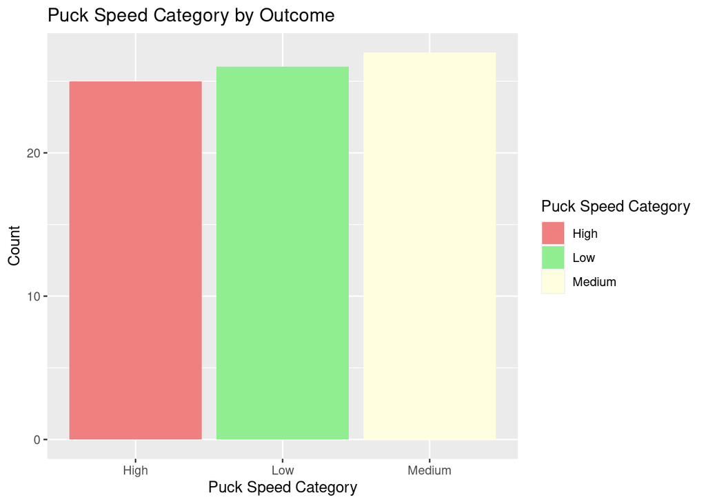

```r
# Define custom colors for each category
category_colors <- c("Low" = "lightgreen", "Medium" = "lightyellow", "High" = "lightcoral")

# Create a bar plot
ggplot(saves_data, aes(x = puckSpeedCategory, fill = puckSpeedCategory)) +
  geom_bar(position = "dodge") +
  scale_fill_manual(values = category_colors) +  # Set custom colors
  labs(
    title = "Puck Speed Category by Outcome",
    x = "Puck Speed Category",
    y = "Count",
    fill = "Puck Speed Category"  # Legend title
  )
```

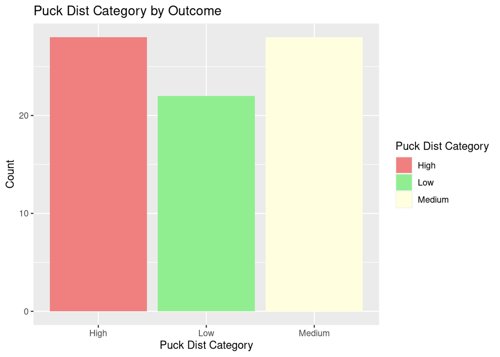

```r
ggplot(saves_data, aes(x = puckDistCategory, fill = puckDistCategory)) +
  geom_bar(position = "dodge") +
  scale_fill_manual(values = category_colors) +  # Set custom colors
  labs(
    title = "Puck Dist Category by Outcome",
    x = "Puck Dist Category",
    y = "Count",
    fill = "Puck Dist Category"  # Legend title
  )
```

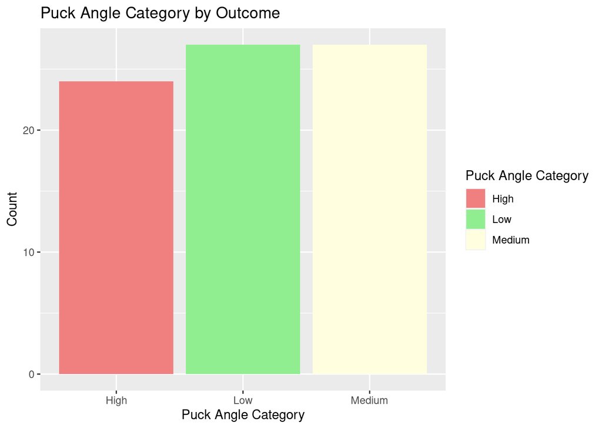

```r
ggplot(saves_data, aes(x = puckAngleCategory, fill = puckAngleCategory)) +
  geom_bar(position = "dodge") +
  scale_fill_manual(values = category_colors) +  # Set custom colors
  labs(
    title = "Puck Angle Category by Outcome",
    x = "Puck Angle Category",
    y = "Count",
    fill = "Puck Angle Category"  # Legend title
  )
```

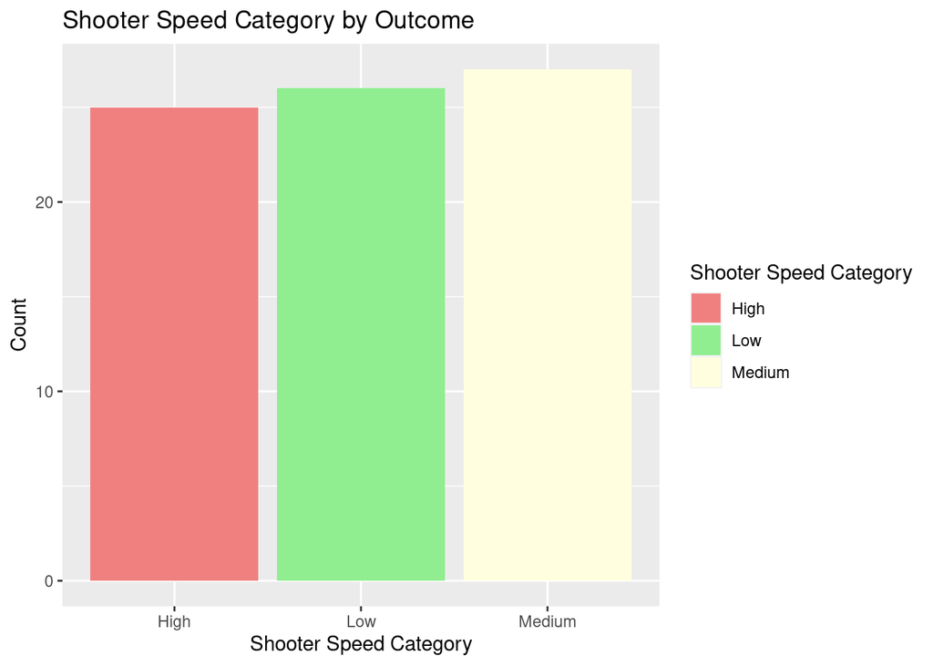

```r
ggplot(saves_data, aes(x = shooterSpeedCategory, fill = shooterSpeedCategory)) +
  geom_bar(position = "dodge") +
  scale_fill_manual(values = category_colors) +  # Set custom colors
  labs(
    title = "Shooter Speed Category by Outcome",
    x = "Shooter Speed Category",
    y = "Count",
    fill = "Shooter Speed Category"  # Legend title
  )
```

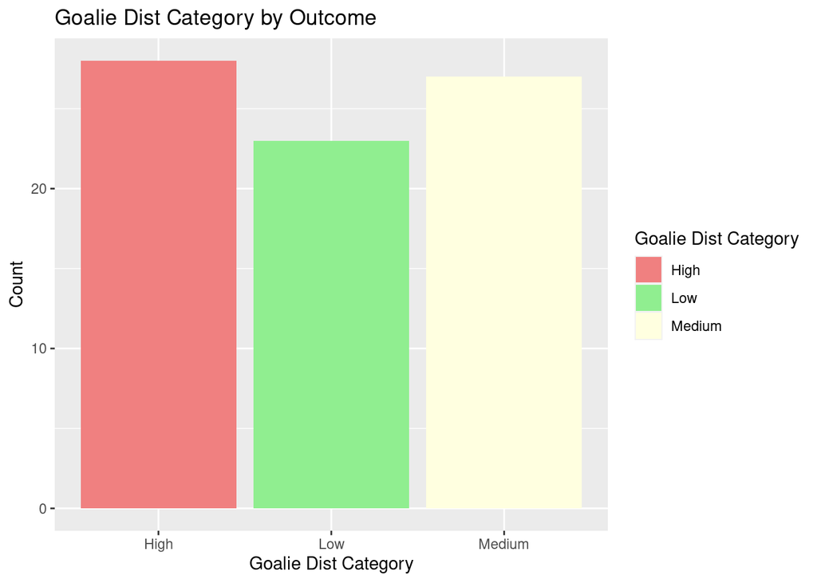

```r
ggplot(saves_data, aes(x = goalieDistCategory, fill = goalieDistCategory)) +
  geom_bar(position = "dodge") +
  scale_fill_manual(values = category_colors) +  # Set custom colors
  labs(
    title = "Goalie Dist Category by Outcome",
    x = "Goalie Dist Category",
    y = "Count",
    fill = "Goalie Dist Category"  # Legend title
  )
```

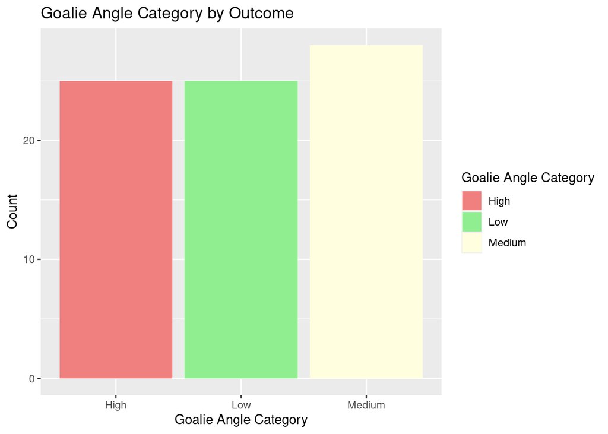

```r
ggplot(saves_data, aes(x = goalieAngleCategory, fill = goalieAngleCategory)) +
  geom_bar(position = "dodge") +
  scale_fill_manual(values = category_colors) +  # Set custom colors
  labs(
    title = "Goalie Angle Category by Outcome",
    x = "Goalie Angle Category",
    y = "Count",
    fill = "Goalie Angle Category"  # Legend title
  )
```

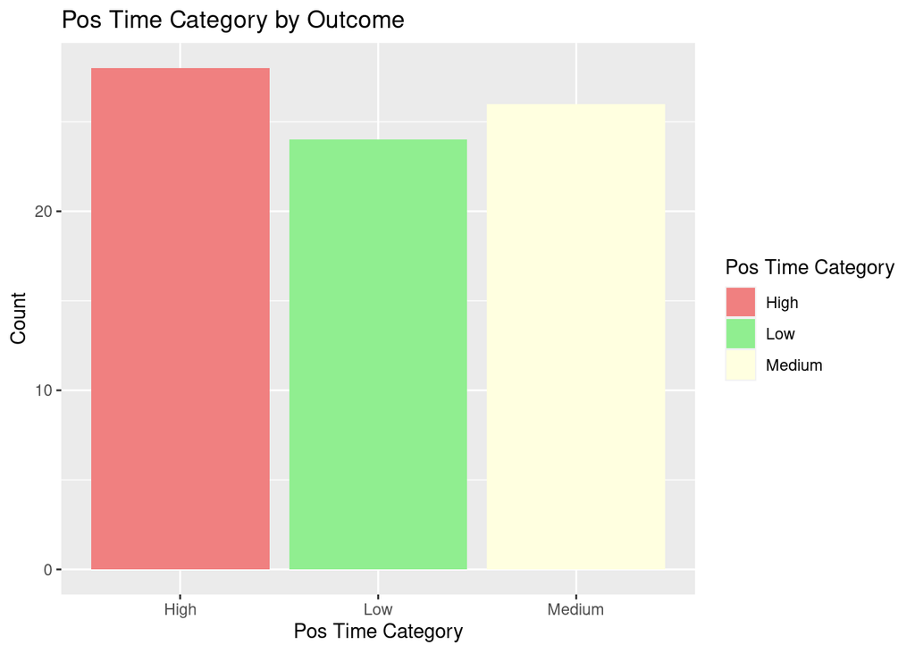

```r
ggplot(saves_data, aes(x = posTimeCategory, fill = posTimeCategory)) +
  geom_bar(position = "dodge") +
  scale_fill_manual(values = category_colors) +  # Set custom colors
  labs(
    title = "Pos Time Category by Outcome",
    x = "Pos Time Category",
    y = "Count",
    fill = "Pos Time Category"  # Legend title
  )
```

### Discussion of results

The results are pretty reasonable. I see that there is a tie between low and medium for puck angle, and some of other variables have a small difference between two categories. But this is due to lack of data, and it looks like this method can explain a lot about modes of failure.

## Analysis: Heat Map of the Modes of Failures

### Question being asked

We have analyzed the modes of failure. Now, I want to find out the relativity between one mode of failure with other modes of failures. More specifically, I want to find out what features are common and correlated when a shot has failed. Also, we will further examine by categorizing continous variables.

### Data Preparation

First, I have created a subset of data which takes in continous variables. Then I found correlation between those varibles and converted it into a matrix so that it can be used for making the heatmap. To make an another heatmap for categorical data, since the heatmap can only take numerical values, I have first converted categorical variables that were continous into binary variables and made a subset of these variables. Then I found the correlation of these variables and graphed into a heatmap.

```r
# Include all data processing code (if necessary), clearly commented

# Define the features that need to be included
keeps <- c("puckDist", "puckAngle", "puckSpeed", "shooterSpeed", "goalieDist", "goalieAngle")

# Create a data frame for the heatmap with
heatmap_data <- saves_data[keeps]

# Find correlation
heatmap_matrix <- cor(heatmap_data[sapply(heatmap_data, is.numeric)])

# Converts categorical variables with 3 categories to binary binary variables
saves_data <- saves_data %>%
  mutate(
    puckSpeedHigh = ifelse(puckSpeedCategory == "High", 1, 0),
    puckSpeedMedium = ifelse(puckSpeedCategory == "Medium", 1, 0),
    puckSpeedLow = ifelse(puckSpeedCategory == "Low", 1, 0),

    puckDistHigh = ifelse(puckDistCategory == "High", 1, 0),
    puckDistMedium = ifelse(puckDistCategory == "Medium", 1, 0),
    puckDistLow = ifelse(puckDistCategory == "Low", 1, 0),

    puckAngleHigh = ifelse(puckAngleCategory == "High", 1, 0),
    puckAngleMedium = ifelse(puckAngleCategory == "Medium", 1, 0),
    puckAngleLow = ifelse(puckAngleCategory == "Low", 1, 0),

    shooterSpeedHigh = ifelse(shooterSpeedCategory == "High", 1, 0),
    shooterSpeedMedium = ifelse(shooterSpeedCategory == "Medium", 1, 0),
    shooterSpeedLow = ifelse(shooterSpeedCategory == "Low", 1, 0),

    goalieDistHigh = ifelse(goalieDistCategory == "High", 1, 0),
    goalieDistMedium = ifelse(goalieDistCategory == "Medium", 1, 0),
    goalieDistLow = ifelse(goalieDistCategory == "Low", 1, 0),

    goalieAngleHigh = ifelse(goalieAngleCategory == "High", 1, 0),
    goalieAngleMedium = ifelse(goalieAngleCategory == "Medium", 1, 0),
    goalieAngleLow = ifelse(goalieAngleCategory == "Low", 1, 0)
  )

# Subset of data to be represented in heatmap
catkeeps <- c("puckSpeedHigh", "puckSpeedMedium", "puckSpeedLow", "puckDistHigh", "puckDistMedium", "puckDistLow", "puckAngleHigh", "puckAngleMedium", "puckAngleLow", "shooterSpeedHigh", "shooterSpeedMedium", "shooterSpeedLow", "goalieDistHigh", "goalieDistMedium", "goalieDistLow", "goalieAngleHigh", "goalieAngleMedium", "goalieAngleLow")

# Now we have added binary variables to saves_data, we can take subset of saves_data
heatmap_catdata <- saves_data[catkeeps]

# Find correlation between binary categorical variables
heatmap_catmatrix <- cor(heatmap_catdata[sapply(heatmap_catdata, is.numeric)])
```

### Analysis: Methods and Results

All data have been prepared above, and heatmap_matrix and heatmap_catmatrix are in appropriate matrix form only with numeric values. We can use the heatmap function to produce a heatmap.

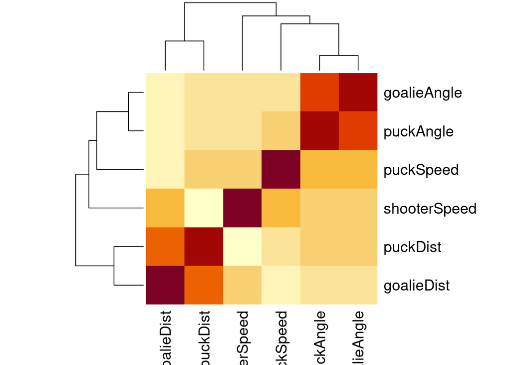

```r
# Include all analysis code, clearly commented
# If not possible, screen shots are acceptable.
# If your contributions included things that are not done in an R-notebook,
#   (e.g. researching, writing, and coding in Python), you still need to do
#   this status notebook in R.  Describe what you did here and put any products
#   that you created in github. If you are writing online documents (e.g. overleaf
#   or google docs), you can include links to the documents in this notebook
#   instead of actual text.

# Heatmap without categorization
heatmap(heatmap_matrix)
```

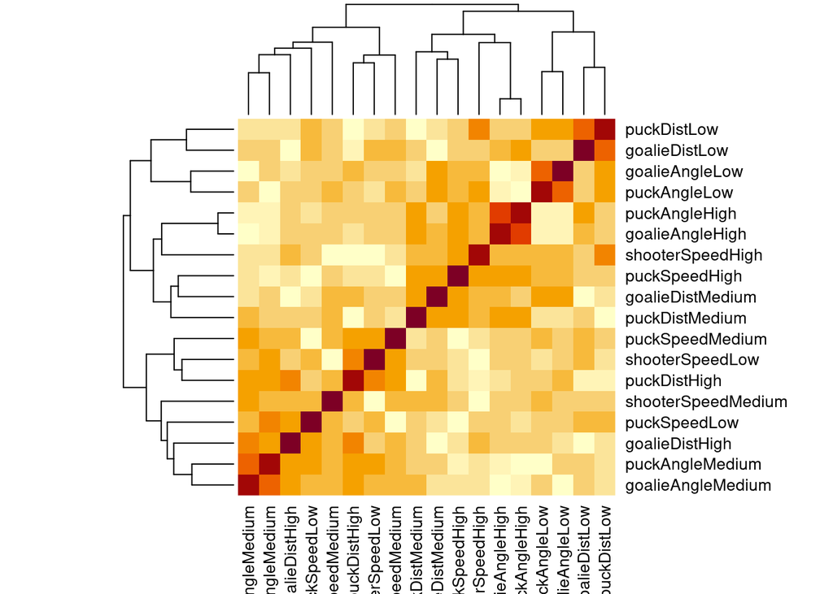

```r
# Heatmap with the categorization
heatmap(heatmap_catmatrix)
```

## Analysis: N/A

### Data Preparation

```r
# Include all data processing code (if necessary), clearly commented
```

### Analysis methods used

```r
# Include all analysis code, clearly commented
# If not possible, screen shots are acceptable.
# If your contributions included things that are not done in an R-notebook,
#   (e.g. researching, writing, and coding in Python), you still need to do
#   this status notebook in R.  Describe what you did here and put any products
#   that you created in github. If you are writing online documents (e.g. overleaf
#   or google docs), you can include links to the documents in this notebook
#   instead of actual text.
```

## Summary and next steps

Next week, I will find some way to incorporate categorical data into cluster analysis.